# BLAST Statistics

Alexander Kaier, Christoph Richard

2025-11-20

# 1 Preface

After having spent some time pondering probability distributions and important corollaries of the strong law of large numbers, we are finally ready to apply everything we have learned to understand how Karlin-Altschul statistics work in the context of BLAST. In order to follow the lecture, we will split this part into two separate sections. The first section will be dedicated to simulating random amino acid sequences and computing alignment scores. From there, we can very quickly estimate the distribution of these alignment scores as well as $\lambda$ and $K$, which are parameters of the distribution.

In the second section, we will go a bit deeper into the simulation of alignment scores as random walks and derive the Karlin-Altschul parameters $\lambda$ and $K$ from first principles.

# 2 The speedrun

## 2.1 Simulating sequences

We first load the *R* package *Biostrings*. It allows to generate and manipulate DNA strings and AA strings. The *pwalign* package allows to perform global and local alignments

```r
library(Biostrings)
library(pwalign)
```

We can readily define the amino acid alphabet that we will use for simulating sequences

```r
(alphabet=AA_ALPHABET[1:20])
```

```
##  [1] "A" "R" "N" "D" "C" "Q" "E" "G" "H" "I" "L" "K" "M" "F" "P" "S" "T" "W" "Y"
## [20] "V"
```

```r
(r=length(alphabet))
```

```
## [1] 20
```

Next, we define the probability of each amino acid to appear at any given position

```r
# Sample a probability for each amino acid and divide by their sum to normalize such that sum(pvec)=1
pu=runif(r); pvec=pu/sum(pu)
```

Now, we write a function that outputs a random amino acid string from the above model.

```r
RSTRING=function(n=1000, p=rep(1/r,r)) {
  # s is a random sample of size n from the alphabet with probabilities pvec
  s=sample(alphabet, prob=p, n,replace=TRUE)
  # Concatenate the vector s into a single string and return it
  paste(s, collapse="")
}
```

For statistical inference, we now generate a target string of length $m$ and 10000 random strings of length $n$.

```r
m=100; n=400
target=RSTRING(m, pvec)
RSequenzen=character(n)
for (i in 1:10000) {
  RSequenzen[i]=RSTRING(n, pvec)
}
RSequenzen[1]
```

```
## [1] "FSSARHASITACSRRSKGAAGCEVSAACRLSDFYLHSHYSQCNGHMHMECLRCRSHCYCV…"
```

## 2.2 Alignment score evaluation

```r
data(PAM40)
S=PAM40[1:20,1:20]
```

Now, we can actually run the alignment

```r
RanAlign=pairwiseAlignment(RSequenzen, target, substitutionMatrix = S, gapOpening = 20, gapExtension = 20, scoreOnly=TRUE, type="local")
length(RanAlign); head(RanAlign)
```

```
## [1] 10000
```

```
## [1] 30 33 39 43 41 34
```

In order to check whether our results coincide with a Gumbel distribution, we load the necessary packages.

```r
library(car)
library(ordinal)
```

We can estimate the parameters of the Gumbel distribution $G(a,b)$ from the data set. If $Y$ is distributed as $G(a,b)$, we then have

$$\mathbb E[Y]=a+b\gamma \ , \qquad \mathbb V[Y]=b^2 \frac{\pi^2}{6}$$

where $\gamma\approx 0.57721$ is the Euler-Mascheroni constant. We estimate $\mathbb E[Y]$ by the arithmetic mean of the data set, and we estimate $\mathbb V[Y]$ by the empirical variance of the data set. This yields the following estimates for $a$ and $b$.

$$b \approx \frac{\sqrt{6}s_Y}{\pi} \ , \qquad a \approx \bar{Y} - b
\gamma$$

```r
bh= sd(RanAlign)*sqrt(6)/pi; ah=mean(RanAlign)-bh*0.57721
c(ah,bh)
```

```
## [1] 33.478775  3.716715
```

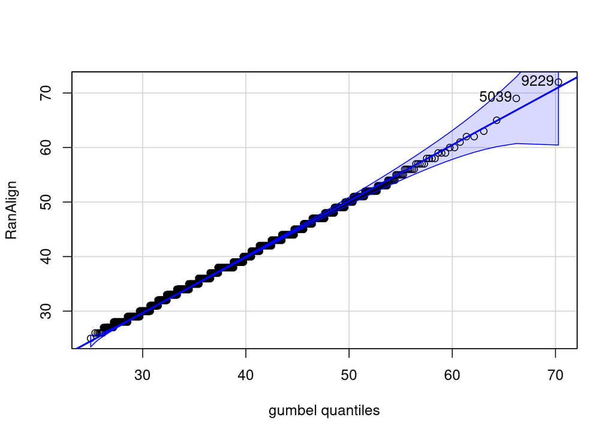

```
## [1] 9229 5039
```

```r
qqPlot(RanAlign, dist="gumbel", location=ah, scale=bh)
```

The canonical form for the parameters of the alignment score distribution is

$$M \approx \frac{\log(K mn)}{\lambda} + \frac{1}{\lambda} X \ ,$$

where $X$ is standard Gumbel distributed. The thus obtain estimates for $\lambda$ and $K$ via the formulae

$$\lambda = \frac{1}{b} \ ,\qquad K=\frac{e^{a/b}}{m n}$$

```r
# this is the estimate for lambda
(lambda = 1/bh)
```

```
## [1] 0.2690548
```

```r
# this is the estimate for K
(K = exp(ah/bh)/(m*n))
```

```
## [1] 0.2041276
```

### 2.2.1 Expected score and parameter estimation

We compute the expectation of the score random variable. For a relevant biological model, it should be negative. Since $\mathbb{P}[S=k]=\sum_{i=1}^r\sum_{j=1}^rp_ip_j\mathbb{1}_{S_{ij}=1}$, we have $\mathbb{E}[S] = \sum_{i=1}^r\sum_{j=1}^rS_{ij}\mathbb{P}[S=k]$

```r
(ES= as.numeric(t(pvec) %*% S %*% pvec))
```

```
## [1] -4.33509
```

In order to determine $\lambda$, we plot the function $x\mapsto \mathbb E[e^{Sx}]$.

```r
fun=function(x) as.numeric(t(pvec) %*% exp(S*x) %*% pvec)
funvec=Vectorize(fun)
```

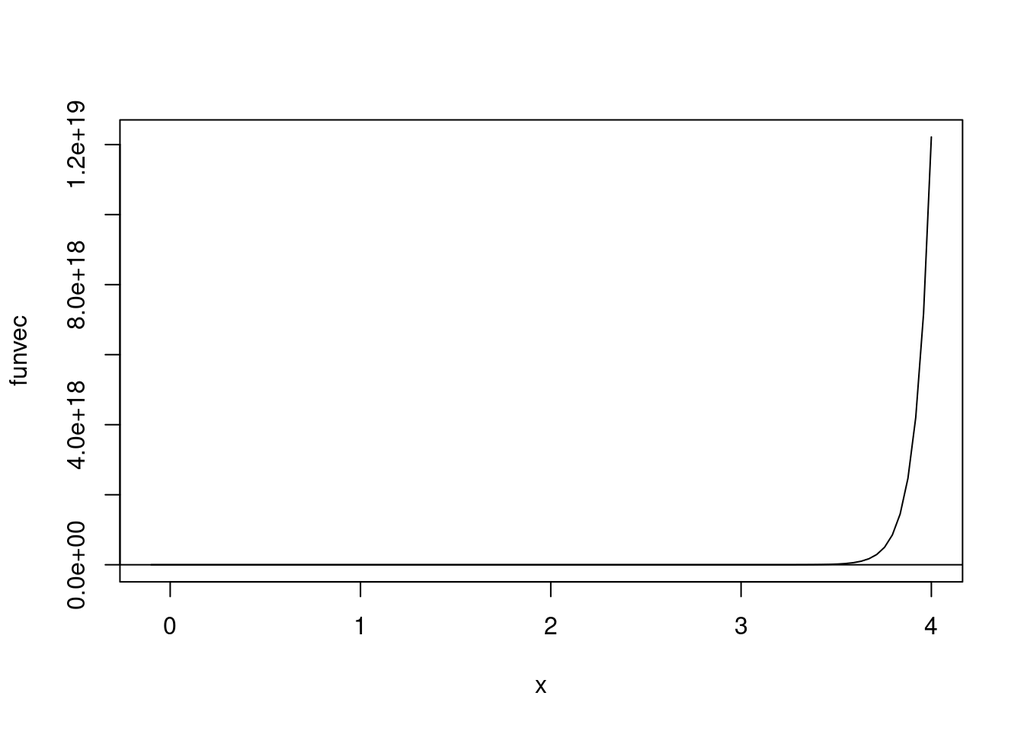

```r
plot(funvec, xlim=c(-0.1,4)); abline(1,0)
```

The parameter $\lambda$ is the unique positive solution of the equation $E[e^{Sx}]=1$. Let us determine a numerical estimate of the solution.

```r
f=function(x) funvec(x)-1
(l=uniroot(f, c(0.04,3))$root)
```

```
## [1] 0.2681214
```

This agrees with the above fit of the Gumbel distribution, up to numerical accuracy.

It is also possible to determine the parameter $K$, using the formula given in the lecture. For simple score matrices taking only integer values larger or equal to $-1$, simple formula arise, that may be compared with the above numerical estimates.

```r
ESlS=as.numeric(t(pvec) %*% (S*exp(S*l)) %*% pvec)
# formula for K
ES^2/ESlS*(1-exp(-l))
```

```
## [1] 0.9074634
```

We have even simpler formulae if $S$ takes only values $-1,0,1$.

```r
# probability that S takes value 1
p=as.numeric(t(pvec) %*% (S==1) %*% pvec)
# probability that S takes value -1
q=as.numeric(t(pvec) %*% (S==-1) %*% pvec)
# formula for lambda
(lambda2 = log(q/p))
```

```
## [1] 0.7562359
```

```r
# formula for K
(K2 = (q-p)^2/q)
```

```
## [1] 0.01300043
```

If we compare these values with our previous estimates, we see that our values diverge for $K$ as well as for $\lambda$. This is because the PAM40 matrix that we used contains values less than $-1$ and also values larger than $1$.

# 3 The long way

## 3.1 Introduction

Since the statistics for alignments has only be thoroughly developed for ungapped alignment and is also only tractable for sequences of equal length, we will restrict ourselves to this case. We will denote the two sequences by $\vec{s}=\{s_1,s_2,...,s_m\}$ and $\vec{t}=\{t_1,t_2,...,t_m\}$. We will also assume that the sequences are generated randomly with probabilities $p_1,p_2,...,p_r$, where we have $r$ different letters in the alphabet (e.g. $r=20$ for amino acids). This is a simplification, but it is a good starting point. We will align these sequences using a scoring matrix $S$. The alignment score is then given by the sum of the scores of the aligned pairs, where the index $i$ indicates the start of the alignment.

$$M' = max\{ \sum_{k=1}^r S_{s_{i+k}t_{i+k}}:1\leq r \leq m, 0 \leq i
\leq m-r\}$$

Note, that in this equation $r$ is not the number of letters in the alphabet but length of the alignment that start at $i$. With the expression for $M'$, we effectively track each alignment score starting from a position $i$ and being of length $r$. The maximum of all these scores is the alignment score $M'$.

## 3.2 The random walk model

The alignment score is a random variable, because the sequences are random. We can think of the alignment score as a random walk on the real line. The random walk starts at 0 and moves up and down according to the scores of the aligned pairs and the gap penalties. The figure below shows an example of such a random walk.

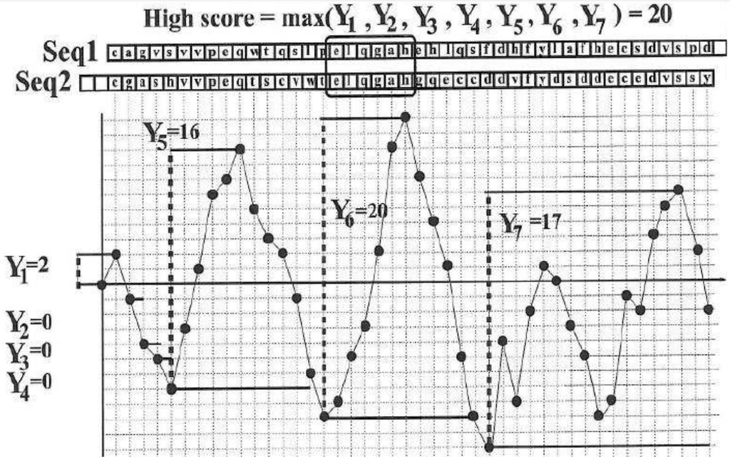

In the figure above, we have two sequences $S$ and $T$ of length $n$ each. The sequences are assumed to be random. This is a very important piece of information for the later interpretation of the alignment statistics. The sequences are aligned and the scores for any pair of amino acids is according to the scoring matrix $S$, which is in this case BLOSUM62, which stands for **blo**ck **su**bstitution **m**atrix. You have heard about it in the lecture. For example, in the alignment above, the score for aligning the amino acid at position 20 (G with G) increases the score by 6, according to the entry of the substitution matrix.

Next, you see that the minimum values (so-called *ladder points*) are connected by horizontal lines. The part of the random walk between such two ladder points is called an *excursion* and represents regions of similarity in the two sequences. The high score is the maximal score of all excursions in the alignment. To stay cosistent with existing literature and the lecture, we call this value the *high scoring pair*, or HSP. It is sometimes also called *high-scoring segment pair*, or HSSP. The fundamental question we are interested for the entire time we spend with BLAST and Karlin-Altschul statistics is the following:

> **Given two random sequences, what is the probability $\mathbb{P}[H_n>k]$ to see a maximum HSP score $H_n=max\{Y_1,Y_2,...,Y_n\}$ above a given threshold k?**

If you think about it, you realize that this statement is the foundation of our trust in BLAST alignment (or any other alignment). If the probability of seeing a maximum alignment score above a certain value just by chance is very low, we can be confident that the alignment is biologically significant. If the probability is high, we cannot be confident that the alignment is significant. This is the reason why we need to understand the statistics of the random walk and the excursions.

Before we simulate real alignments, however, we will write a little algorithm that extracts the HSP scores and positions from a given alignment. We do so using the following toy running alignment scores:

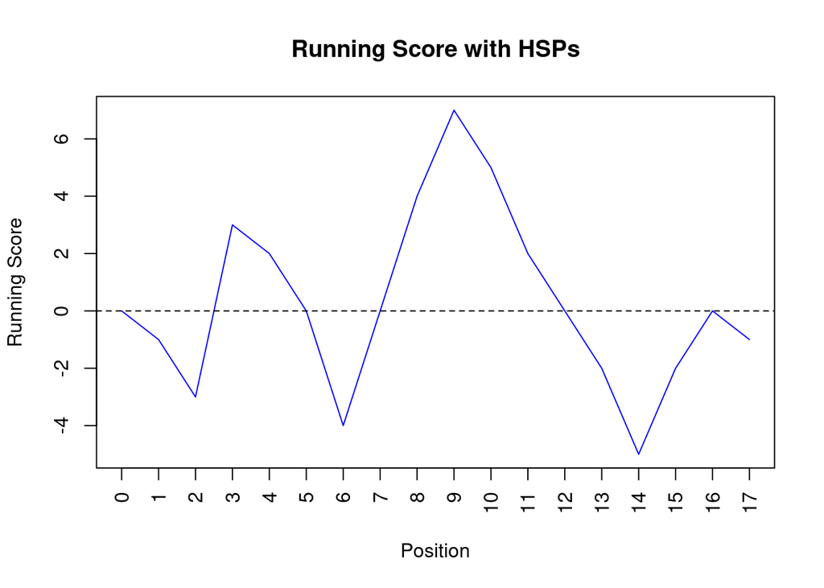

```r
running_score <- c(0, -1, -3, 3, 2, 0, -4, 0, 4, 7, 5, 2, 0, -2, -5, -2,
    0, -1)
plot(0:(length(running_score) - 1), running_score, type = "l", xlab = "Position",
    ylab = "Running Score", main = "Running Score with HSPs", xaxt = "n",
    col = "blue")
axis(1, at = seq(0, 17), las = 2)
abline(h = 0, lty = 2)
```

From the first Figure we can see that the HSPs are the regions between the ladder points. We can extract the HSPs from the running score by looking for the points where the running score crosses the zero line. We can then extract the HSPs by looking at the regions between the ladder points. The following code does this:

```r
# Function to extract HSP positions and scores
extract_hsp <- function(running_score) {
    hsp_positions <- c()
    hsp_scores <- c()

    current_min <- 0  # The alignment starts with a value of 0
    start_pos <- 1  # Starting position of the first HSP
    min_positions <- numeric(0)  # Store positions of local minima
    max_positions <- numeric(0)  # Store positions of local maxima

    # Start the loop at index 2 and find a local minima
    for (i in seq_along(running_score)[-1]) {
        if (running_score[i] < current_min) {
            # Append the current position to the list of local minima
            min_positions <- c(min_positions, i - 1)
            current_min <- running_score[i]
        }
    }

    # Get the maximum value between each pair of local minima
    for (i in seq_along(min_positions)[-1]) {
        start_pos <- min_positions[i - 1] + 1
        end_pos <- min_positions[i]
        max_positions <- c(max_positions, which.max(running_score[start_pos:end_pos]) +
            start_pos - 2)
    }

    # Create a dataframe with according minima and maxima We do not
    # need the last minimum value, since no HSP can be defined after
    # that because there is no ladder point afterwards
    hsp_positions <- data.frame(start = min_positions[-length(min_positions)],
        end = max_positions)

    hsp_positions["score"] <- ifelse(hsp_positions$start == hsp_positions$end,
        running_score[hsp_positions$end + 2] - running_score[hsp_positions$start +
            1], running_score[hsp_positions$end + 1] - running_score[hsp_positions$start +
            1])
    return(hsp_positions)
}

# Extract HSPs
hsps <- extract_hsp(running_score)
```

Let us plot our toy alignment again, but this time with the HSPs marked using ggplot:

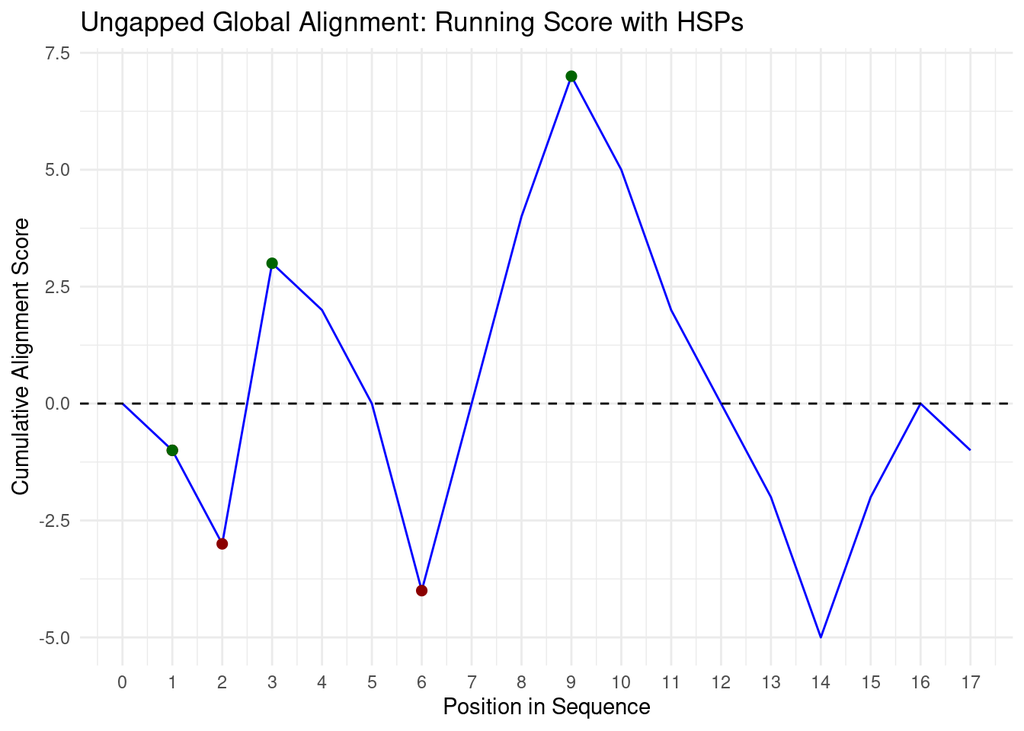

In our toy example, we have already extracted three HSPs, corresponding to three local alignments in a real sequence alignment.

```r
hsps
```

```
##   start end score
## 1     1   1    -2
## 2     2   3     6
## 3     6   9    11
```

## 3.3 The easy case

We will start with an easy scenario and estimate $\lambda$ and $K$ in a straight forward way. Consider the alignment of two DNA sequences sequences with the following substitution matrices:

```r
# Define the scoring matrix (re)
S <- matrix(c(1, 0, -1, -1, 0, 1, -1, -1, -1, -1, 1, 0, -1, -1, 0, 1),
    nrow = 4, byrow = TRUE)
rownames(S) <- colnames(S) <- c("A", "G", "C", "T")
S
```

```
##    A  G  C  T
## A  1  0 -1 -1
## G  0  1 -1 -1
## C -1 -1  1  0
## T -1 -1  0  1
```

The random walk of an alignment of random sequences looks then as follows:

```r
# Step 2: Generate random protein sequences
generate_random_sequence <- function(n, substitution_matrix) {
    sample(rownames(substitution_matrix), n, replace = TRUE)  # Use amino acid symbols from BLOSUM62
}

seq1 <- generate_random_sequence(50, S)  # Random sequence 1
seq2 <- generate_random_sequence(50, S)  # Random sequence 2

# Step 3: Ungapped alignment and score calculation
ungapped_global_alignment <- function(seq1, seq2, scoring_matrix) {
    # Ensure sequences are the same length
    if (length(seq1) != length(seq2)) {
        stop("Sequences must be of the same length for ungapped global alignment.")
    }

    running_scores <- numeric(length(seq1))  # Store cumulative scores at each step
    total_score <- 0

    # Compute the score for each position
    for (i in seq_along(seq1)) {
        match_score <- scoring_matrix[seq1[i], seq2[i]]
        total_score <- total_score + match_score
        running_scores[i] <- total_score
    }

    list(total_score = total_score, running_scores = running_scores)
}

# Run the ungapped global alignment
alignment_result <- ungapped_global_alignment(seq1, seq2, S)

# Step 4: Plot the random walk of alignment scores
running_scores <- alignment_result$running_scores
running_scores <- c(0, running_scores)  # Add the initial score of 0
```

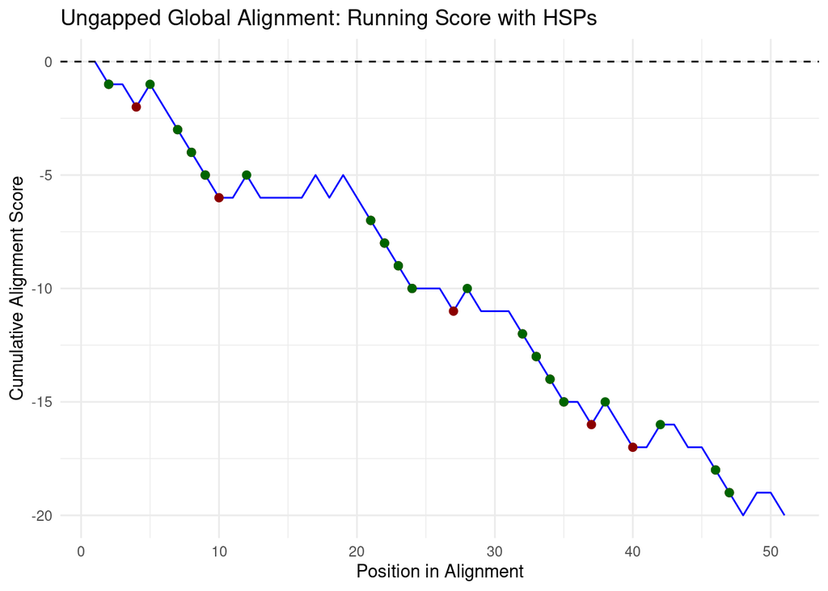

```r
hsps <- extract_hsp(running_scores)

# Create a data frame for visualization
score_data <- data.frame(Position = seq_along(running_scores), Score = running_scores)

# Plot the running score with HSPs
ggplot(score_data, aes(x = Position, y = Score)) + geom_line(color = "blue") +
    geom_point(data = score_data[hsps$start + 1, , drop = FALSE], aes(x = Position,
        y = Score), color = "darkred", size = 2) + geom_point(data = score_data[hsps$end +
    1, , drop = FALSE], aes(x = Position, y = Score), color = "darkgreen",
    size = 2) + theme_minimal() + geom_hline(yintercept = 0, linetype = "dashed") +
    labs(title = "Ungapped Global Alignment: Running Score with HSPs",
        x = "Position in Alignment", y = "Cumulative Alignment Score")
```

Now we will create a database from which we can estimate nucleotide probabilities.

```r
# Load the library
library(seqinr)
# Read the chromosome of the DM6.1 potato reference genome
seqs <- read.fasta(file = "Data/Stub_chr01.fasta", seqtype = "DNA")[[1]]

seqs <- toupper(seqs)
nc_abs_freq <- table(seqs)
nc_abs_freq <- nc_abs_freq[names(nc_abs_freq) %in% rownames(S)]
# Calculate the nucleotide frequencies
nc_freq <- nc_abs_freq/sum(nc_abs_freq)

# Print the amino nucleotide frequencies
nc_freq
```

```
## seqs
##         A         C         G         T
## 0.3254044 0.1742260 0.1743111 0.3260585
```

We should not forget that one assumption of Karlin-Altschul statistics is that the expectation of the alignment score $S_{ij}$ between any two nucleotides should be negative. We can check that easily as you see:

```r
# Calculate the expected score
(ES = as.numeric(t(nc_freq) %*% S %*% nc_freq))
```

```
## [1] -0.2270585
```

## 3.4 Estimating lambda and K

Within the lecture, you have seen that $\lambda$ and $K$ can be calculated quite easily, if $S_{ij} \in \{-1,0,1\}$. If this is the case and the assumption hold, which they do, than we get the following equations for $\lambda$ and $K$:

$$\begin{align}
\lambda &= log(\frac{q}{p}) \\
K &= \frac{(q-p)^2}{q}
\end{align}$$

```r
# Create a 2d grid of nucleotide frequencies
nc_freq_grid <- outer(nc_freq, nc_freq)
p <- sum(nc_freq_grid[S == 1])
q <- sum(nc_freq_grid[S == -1])

# Look into Section 5.2.3 of the lecture for the equations
lambda <- log(q/p)
K <- ((q - p)^2)/q

lambda
```

```
## [1] 0.6053511
```

```r
K
```

```
## [1] 0.1031112
```

Now we cam simulate many pairwise alignments and collect the max scores. We will then plot the distribution of these max scores and overlay the Gumbel distribution with according parameters.

```r
# Redefine the sequence generation function to include nucleotide
# frequencies
generate_random_sequence_freqs <- function(n, substitution_matrix) {
    sample(rownames(substitution_matrix), n, replace = TRUE, prob = nc_freq[order(rownames(S))])  # Use amino acid symbols from BLOSUM62
}
# Define the number of alignments that should be simulated
n_alignments <- 10000
seq_length <- 1000
max_scores <- numeric(n_alignments)
# Create pairwise alignments and extract the maximal HSP score for
# each alignment.
for (i in 1:n_alignments) {
    seq1 <- generate_random_sequence_freqs(seq_length, S)
    seq2 <- generate_random_sequence_freqs(seq_length, S)
    alignment_result <- ungapped_global_alignment(seq1, seq2, S)
    running_scores <- alignment_result$running_scores
    running_scores <- c(0, running_scores)  # Add the initial score of 0
    hsps <- extract_hsp(running_scores)
    max_scores[i] <- max(hsps$score)
}
```

Now we plot the CDF of the max scores and compare it to the Gumbel distribution.

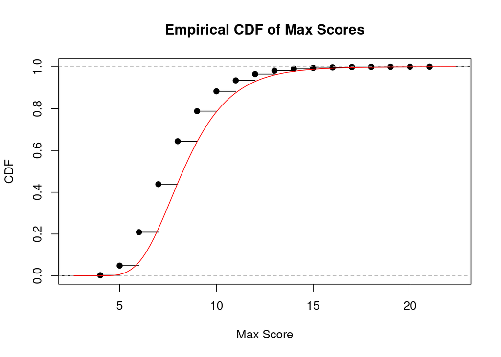

```r
library(ordinal)

# Calculate the empirical CDF
empirical_cdf <- ecdf(max_scores)
plot(empirical_cdf, main = "Empirical CDF of Max Scores", xlab = "Max Score",
    ylab = "CDF")
# Calculate the parameters for the Gumbel distribution according to
# Section 5.2.1 of the lecture
a_m <- log(seq_length * K)/lambda
b <- 1/lambda
# Plot the Gumbel distribution
curve(pgumbel(x, loc = a_m, scale = b), add = TRUE, col = "red")
```

Now we can calculate $p$-values for each alignment:

```r
# Calculate the p-values (remember that the p-value is the
# probability to observe a score equal to or larger than S)
p_values <- 1 - pgumbel(max_scores, loc = a_m, scale = b)
```

In the lecture, we see that the number of alignments with a certain score follows a Poisson distribution $\mathbb{P}[N_s|y_s]=\frac{e^{-y_s}(y_s)^k}{k!}$ with parameter $y_s=Kmne^{-\lambda s}$. The expectation of the distribution is then the $E$-value for that score.

```r
# Calculate the E-values (this is done using the expectation of the
# Poisson distribution P[Ns=K|y] using y=Kmne)
E_values <- K * (seq_length^2) * exp(-lambda * max_scores)

# Threshold for k for which we say m is sufficiently large
k_threshold <- log(1000)/lambda
```

If you recorded them before, now you may select and closer investigate those alignments for which you deem the p-values or E-values sufficiently low.

## 3.5 A more realistic example

Now we will look at a more realistic example and see how far we can go. We will conduct pairwise sequence alignment using protein sequences and the BLOSUM62 matrix. We will again check if the expectation value of the score is $\mathbb{E}[S_{ij}]<0$ for amino acid frequencies that we draw from a real database.

```r
data(BLOSUM62, package = "pwalign")
# Remove non-standard amino acids from the matrix
BLOSUM62 <- BLOSUM62[!rownames(BLOSUM62) %in% c("B", "J", "Z", "X", "*"),
    !colnames(BLOSUM62) %in% c("B", "J", "Z", "X", "*")]
BLOSUM62
```

```
##    A  R  N  D  C  Q  E  G  H  I  L  K  M  F  P  S  T  W  Y  V
## A  4 -1 -2 -2  0 -1 -1  0 -2 -1 -1 -1 -1 -2 -1  1  0 -3 -2  0
## R -1  5  0 -2 -3  1  0 -2  0 -3 -2  2 -1 -3 -2 -1 -1 -3 -2 -3
## N -2  0  6  1 -3  0  0  0  1 -3 -3  0 -2 -3 -2  1  0 -4 -2 -3
## D -2 -2  1  6 -3  0  2 -1 -1 -3 -4 -1 -3 -3 -1  0 -1 -4 -3 -3
## C  0 -3 -3 -3  9 -3 -4 -3 -3 -1 -1 -3 -1 -2 -3 -1 -1 -2 -2 -1
## Q -1  1  0  0 -3  5  2 -2  0 -3 -2  1  0 -3 -1  0 -1 -2 -1 -2
## E -1  0  0  2 -4  2  5 -2  0 -3 -3  1 -2 -3 -1  0 -1 -3 -2 -2
## G  0 -2  0 -1 -3 -2 -2  6 -2 -4 -4 -2 -3 -3 -2  0 -2 -2 -3 -3
## H -2  0  1 -1 -3  0  0 -2  8 -3 -3 -1 -2 -1 -2 -1 -2 -2  2 -3
## I -1 -3 -3 -3 -1 -3 -3 -4 -3  4  2 -3  1  0 -3 -2 -1 -3 -1  3
## L -1 -2 -3 -4 -1 -2 -3 -4 -3  2  4 -2  2  0 -3 -2 -1 -2 -1  1
## K -1  2  0 -1 -3  1  1 -2 -1 -3 -2  5 -1 -3 -1  0 -1 -3 -2 -2
## M -1 -1 -2 -3 -1  0 -2 -3 -2  1  2 -1  5  0 -2 -1 -1 -1 -1  1
## F -2 -3 -3 -3 -2 -3 -3 -3 -1  0  0 -3  0  6 -4 -2 -2  1  3 -1
## P -1 -2 -2 -1 -3 -1 -1 -2 -2 -3 -3 -1 -2 -4  7 -1 -1 -4 -3 -2
## S  1 -1  1  0 -1  0  0  0 -1 -2 -2  0 -1 -2 -1  4  1 -3 -2 -2
## T  0 -1  0 -1 -1 -1 -1 -2 -2 -1 -1 -1 -1 -2 -1  1  5 -2 -2  0
## W -3 -3 -4 -4 -2 -2 -3 -2 -2 -3 -2 -3 -1  1 -4 -3 -2 11  2 -3
## Y -2 -2 -2 -3 -2 -1 -2 -3  2 -1 -1 -2 -1  3 -3 -2 -2  2  7 -1
## V  0 -3 -3 -3 -1 -2 -2 -3 -3  3  1 -2  1 -1 -2 -2  0 -3 -1  4
```

```r
# Set a random seed for reproducibility
set.seed(42)
# Sample random protein sequences
seq1 <- generate_random_sequence(50, BLOSUM62)  # Random sequence 1
seq2 <- generate_random_sequence(50, BLOSUM62)  # Random sequence 2

# Run the ungapped global alignment using equal probabilities for
# each amino acid
alignment_result <- ungapped_global_alignment(seq1, seq2, BLOSUM62)

# Step 4: Plot the random walk of alignment scores
running_scores <- alignment_result$running_scores
running_scores <- c(0, running_scores)  # Add the initial score of 0
```

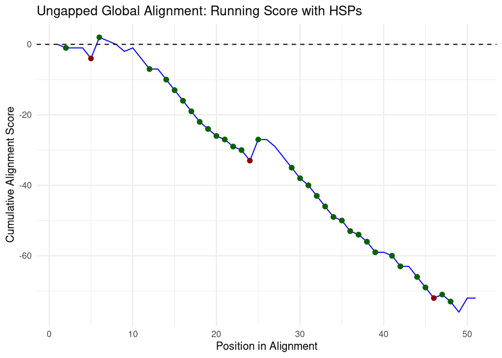

```r
hsps <- extract_hsp(running_scores)

# Create a data frame for visualization
score_data <- data.frame(Position = seq_along(running_scores), Score = running_scores)

# Plot the running score with HSPs
ggplot(score_data, aes(x = Position, y = Score)) + geom_line(color = "blue") +
    geom_point(data = score_data[hsps$start + 1, , drop = FALSE], aes(x = Position,
        y = Score), color = "darkred", size = 2) + geom_point(data = score_data[hsps$end +
    1, , drop = FALSE], aes(x = Position, y = Score), color = "darkgreen",
    size = 2) + theme_minimal() + geom_hline(yintercept = 0, linetype = "dashed") +
    labs(title = "Ungapped Global Alignment: Running Score with HSPs",
        x = "Position in Alignment", y = "Cumulative Alignment Score")
```

```r
seq1
```

```
##  [1] "T" "C" "A" "I" "D" "W" "T" "P" "E" "D" "C" "F" "V" "W" "P" "N" "H" "D" "C"
## [20] "M" "C" "V" "R" "G" "N" "A" "I" "L" "P" "G" "D" "D" "W" "M" "C" "D" "R" "W"
## [39] "N" "T" "W" "Q" "Q" "R" "V" "N" "R" "Q" "I" "G"
```

```r
seq2
```

```
##  [1] "C" "A" "T" "E" "D" "M" "I" "H" "K" "V" "H" "L" "N" "S" "C" "F" "C" "R" "W"
## [20] "T" "W" "C" "F" "G" "G" "D" "D" "E" "I" "W" "M" "Y" "S" "T" "K" "H" "L" "S"
## [39] "G" "Q" "A" "M" "F" "C" "H" "S" "L" "I" "I" "A"
```

```r
# Extract the maximum HSP score
max_hsp_score <- max(hsps$score)
```

## 3.6 Obtaining a database

You can download the database using the following code in the bash shell (the filename is truncated in the command below. The full file name is `https://ftp.uniprot.org/pub/databases/uniprot/current_release/` `knowledgebase/complete/uniprot_sprot.fasta.gz`):

```bash
# Download the database using the wget command (navigate into the Data folder before downloading it)
wget https://ftp.uniprot.org/pub/databases/uniprot/current_release/knowledgebase/complete/uniprot_sprot.fasta.gz
# Unzip the database
gunzip uniprot_sprot.fasta.gz
```

We will now calculate the amino acid frequencies from the database. We will use the first 1000 sequences of the database to calculate the frequencies. The following bash code does this:

```bash
# Be sure you are within the Data directory or explicitly tell bash where the input and output files are
awk '/^>/{n++} n>1000{exit} {print}' uniprot_sprot.fasta > uniprot_sprot_first_1000.fasta
```

```r
# Load the library
library(seqinr)

# Read the first 1000 sequences from the database
seqs <- read.fasta(file = "Data/uniprot_sprot_first_1000.fasta", seqtype = "AA")

seqs <- unlist(seqs)
aa_abs_freq <- table(seqs)
aa_abs_freq <- aa_abs_freq[names(aa_abs_freq) %in% rownames(BLOSUM62)]
# Calculate the amino acid frequencies
aa_freq <- aa_abs_freq/sum(aa_abs_freq)

# Print the amino acid frequencies
aa_freq
```

```
## seqs
##          A          C          D          E          F          G          H
## 0.07143749 0.02077930 0.05586229 0.07086412 0.04029720 0.05778473 0.02268151
##          I          K          L          M          N          P          Q
## 0.05694493 0.06201749 0.09573453 0.02668492 0.04728210 0.04392625 0.03941018
##          R          S          T          V          W          Y
## 0.05325855 0.07079667 0.05102918 0.06195678 0.01346388 0.03778790
```

```r
# Check if the frequencies add up to 1
sum(aa_freq)
```

```
## [1] 1
```

As before, we should check whether $\mathbb{E}[S_{ij}]<0$.

```r
S <- BLOSUM62  # Rename the scoring matrix for easier handling (take note that the other scoring matrix is overwritten)
# Calculate the expected score
(ES = as.numeric(t(aa_freq) %*% S %*% as.numeric(aa_freq)))
```

```
## [1] -1.058038
```

So far so good. We can now continue to estimate $\lambda$, but this time in a different way than before.

## 3.7 Estimating $\lambda$

Before, we calculated $lambda$ using the fact that $S_{ij} \in \{-1,0,1\}$, which allowed us to use the equation $\lambda = log(\frac{q}{p})$, where $p := \mathbb{P}[S_{ij}=1]$ and $q := \mathbb{P}[S_{ij}=-1]$. However, the BLOSUM62 matrix is not so simple, so we need to find another way to estimate $\lambda$.In lecture section 5.1.1, you see that $\lambda$ is the unique solution to the following equation:

$$\begin{equation}
\mathbb{E}[e^{Sx}] = \sum_{i=1}^r \sum_{j=1}^r p_i p_j e^{S_{ij}x} =
1,\quad \text{when}\;x=\lambda \geq0
\end{equation}$$

Before we actually estimate $\lambda$, let us briefly assert that there must indeed exist such an $x=\lambda$ that fulfills the equation. A little calculus and curve-sketching gets us a long way. Let $f(x) = \sum_{i=1}^r \sum_{j=1}^r p_i p_j e^{S_{ij}x}$. Then the following observations can be made:

1. $f(0) = \sum_{i=1}^r \sum_{j=1}^r p_i p_j = 1$.
2. $f'(0) = \sum_{i=1}^r \sum_{j=1}^r p_i p_j S_{ij} = \mathbb{E}[S] < 0$.
3. $f''(x) = \sum_{i=1}^r \sum_{j=1}^r p_i p_j S_{ij}^2 e^{S_{ij}x}> 0$.
4. $f(x)$ diverges for large $x$, because at least one $S_{ij}>0$.

These observations imply that $f(x)$ is a convex function. This means that there must be a unique solution for $x=\lambda$ that fulfills the equation $f(x)=1$. The figure below shows the function $f(x)$.

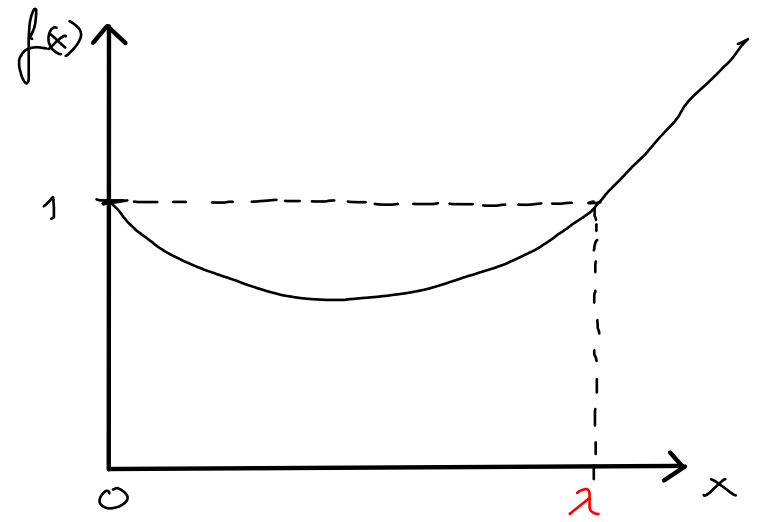

For the estimation of $\lambda$, we need the marginal probabilities of the amino acids, which we have already calculated before:

```r
# Inputs
tol <- 1e-05  # Tolerance for convergence of lambda
lambda <- 0.25  # Initialize a starting value for lambda that is going to be updated
lambda_lower <- 0  # Initialize a lower limit for lambda that is going to be updated
lambda_upper <- NULL  # Initialize an upper limit for lambda that is going to be updated

# Step 1: Outer Loop - Doubling Lambda
repeat {
    sum <- 0
    check <- 0
    for (i in 1:length(aa_freq)) {
        for (j in 1:length(aa_freq)) {
            if (aa_freq[i] > 0 && aa_freq[j] > 0) {
                sum <- sum + aa_freq[i] * aa_freq[j] * exp(lambda * S[i,
                  j])
                check <- check + aa_freq[i] * aa_freq[j]
            }
        }
    }

    stopifnot(check > 0.999 && check < 1.001)  # Assert check condition

    if (sum >= 1)
        break

    lambda_lower <- lambda
    lambda <- lambda * 2
}

lambda_upper <- lambda

# Step 2: Bisection Method
while ((lambda_upper - lambda_lower) > tol) {
    lambda <- (lambda_lower + lambda_upper)/2
    sum <- 0
    check <- 0
    for (i in 1:length(aa_freq)) {
        for (j in 1:length(aa_freq)) {
            if (aa_freq[i] > 0 && aa_freq[j] > 0) {
                sum <- sum + aa_freq[i] * aa_freq[j] * exp(lambda * S[i,
                  j])
                check <- check + aa_freq[i] * aa_freq[j]
            }
        }
    }

    stopifnot(check > 0.999 && check < 1.001)  # Assert check condition

    if (sum >= 1) {
        lambda_upper <- lambda
    } else {
        lambda_lower <- lambda
    }
}

# Final result
lambda
```

```
## [1] 0.2661057
```

This procedure above is the actual algorithm that BLAST uses for the calculation of the parameter $\lambda$. In the [BLAST source code](https://www.ncbi.nlm.nih.gov/IEB/ToolBox/C_DOC/lxr/source/algo/blast/core/blast_stat.c), you can find the code for the calculation of $\lambda$ in the lines 1282-1327. Here is a little explanation about the code:

The first loop can be regarded as a coarse-grained approach to push the initial value for $\lambda$ into the right direction. It starts with an arbitrary value for lambda and checks whether $\mathbb{E}[e^{Sx}]>1$. As long as this is not the case, $\lambda$ gets doubled and we update the lower boundary for lambda such that it is the former value for lambda, which was too small. As soon as $\mathbb{E}[e^{Sx}]>1$, we break out of the first loop and go to the second one. This loop fine-tunes $\lambda$ to lie within a certain tolerance boundary region that we defined beforehand. As long as the boundary values are farther apart than the tolerance threshold, we shift $\lambda$ to lie in the middle between the boundaries and update a boundary value depending on whether $\mathbb{E}[e^{Sx}]$ is greater or smaller than 1. We do this until the boundaries are sufficiently close to each other at which point we claim that we have estimated $\lambda$ to a sufficient degree.

Try to visualize the process using the figure for $f(x)$ that we have drawn above. The algorithm is visually quite intuitive.

At this point we stop our simulation of BLAST, since the $K$ parameter is much more difficult to estimate compared to $\lambda$. We will continue with a real BLAST search and the analysis of the results.

# 4 Conclusion

This part of the practical course should serve you as a refresher of some parts of the lecture concerning the Karlin-Altschul statistics. You have seen how certain equations from the lecture can be implemented using simulations in order to estimate parameters for the Gumbel distribution. You have also seen that this distribution, if tweaked using the right parameters, approximates the maximum alignment scores quite accurately. This fact allows us to draw statistical inference from our alignments and gives us permission to distinguish between alignments that we deem to occur due to chance and those that are likely due to biological processes, e.g. ortholog and paralog genes.